# Anova comparison of datasets

Padraig Lucey

2022-08-22

## ANOVA comparison of all datasets

We are assessing the comparability of cows across all provided data-sets for inclusion in a compiled data-set. A data-set of all cows in all datasets will be used to draw random samplings of cows that represent pens on a dairy. These simulated pens will be used to fit the distribution of Dry Matter Intake (DMI) and other group level parameters will train a model that predict this distribution function. Before we can combine these data-sets together it is important to validate that the cows across the different data-sets are comparable metabolically, so that the assessment of DMI and the plotting of DMI distribution across the constructed pen groups is appropriate.

ANOVA compares two or more groups for a difference in group means. This is performed by comparing the variance between groups against the variance within each group. If the variance between groups is significantly larger than the variance within each group then the groups are considered significantly different.

The means of the values for milk production (kg), DMI (kg) and feed efficiency (fat corrected milk(FCM) (kg)/DMI (kg)) by data-set will be compared using ANOVA statistical analysis. Pairwise comparison of the group means, and visual assessment of the marginal values of each of these three outcomes will be used to assess the comparability of the data-sets and guide decision criteria for inclusion in a collated data-set.

## Data description

### Number of cows in all data-sets

Table 1.

| Data-set | 1 | 2 | 3 | 4 | 5 | 6 | 7 | 8 | 9 | Total |
| --- | --- | --- | --- | --- | --- | --- | --- | --- | --- | --- |
| Number of Cows | 55 | 74 | 37 | 45 | 40 | 31 | 51 | 36 | 57 | 426 |

### Milk production

This plot demonstrates how milk production (kg) changes by week across the lactation for all cows in each data-set. Figure 1.

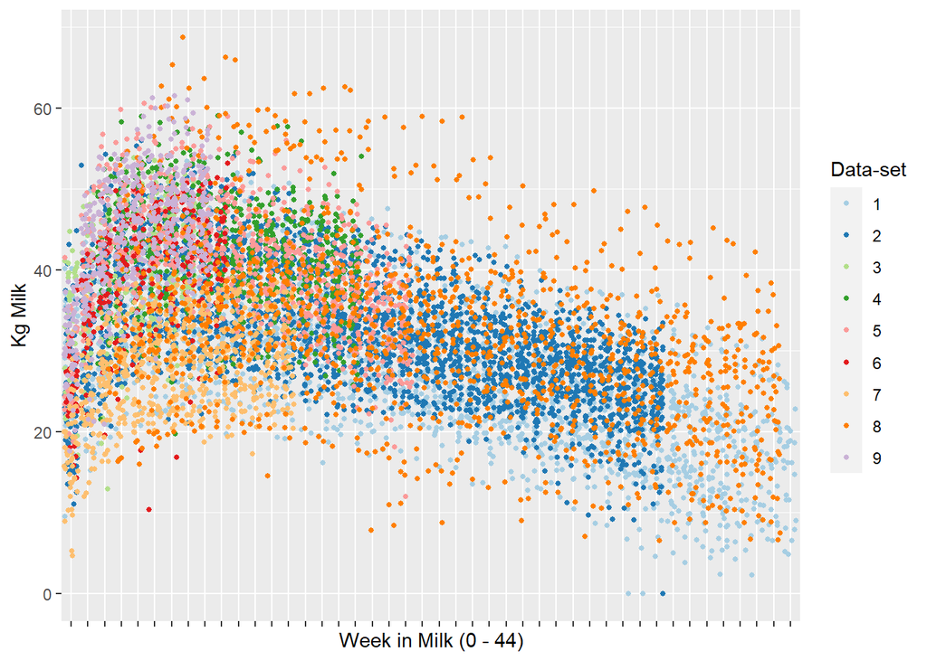

### Dry matter intake

This plot demonstrates how DMI (kg) changes by week across the lactation for all cows in each data-set. Figure 2.

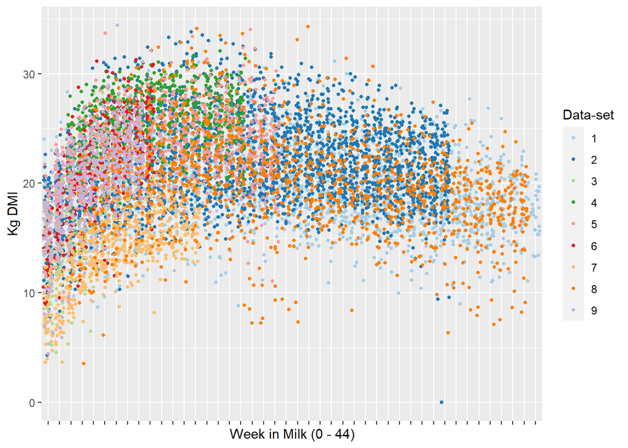

### Feed Efficiency

This plot demonstrates how Feed Efficiency (kg fat corrected milk/kg DMI)) changes by week across the lactation for all cows in each data-set. Figure 3.

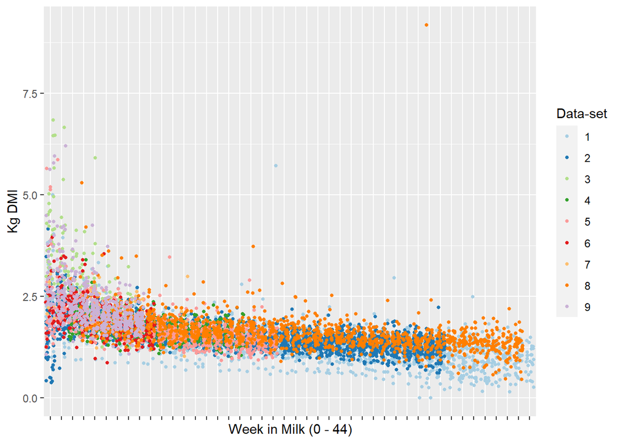

### Box-plots of milk yield (kg) by week for each data-set

Figure-set 4.

#### Week 1

| Data-set | 1 | 2 | 3 | 4 | 5 | 6 | 7 | 8 | 9 |
| --- | --- | --- | --- | --- | --- | --- | --- | --- | --- |
| Mean | 27.15229 | 24.67921 | 32.94156 |  | 26.98902 | 25.16452 | 18.08291 |  | 30.66473 |
| Median | 26.95714 | 23.58705 | 33.65690 |  | 25.53751 | 25.60000 | 18.00000 |  | 30.26542 |
| Standard Deviation | 6.750860 | 7.486358 | 7.407819 |  | 4.916402 | 5.058099 | 5.717061 |  | 4.774092 |
| Minimum | 9.485714 | 11.075327 | 17.100608 | Inf | 18.824277 | 14.300000 | 4.700000 | Inf | 17.642045 |
| Maximum | 40.14286 | 44.84131 | 44.77003 | -Inf | 41.50413 | 37.50000 | 32.42857 | -Inf | 38.74026 |

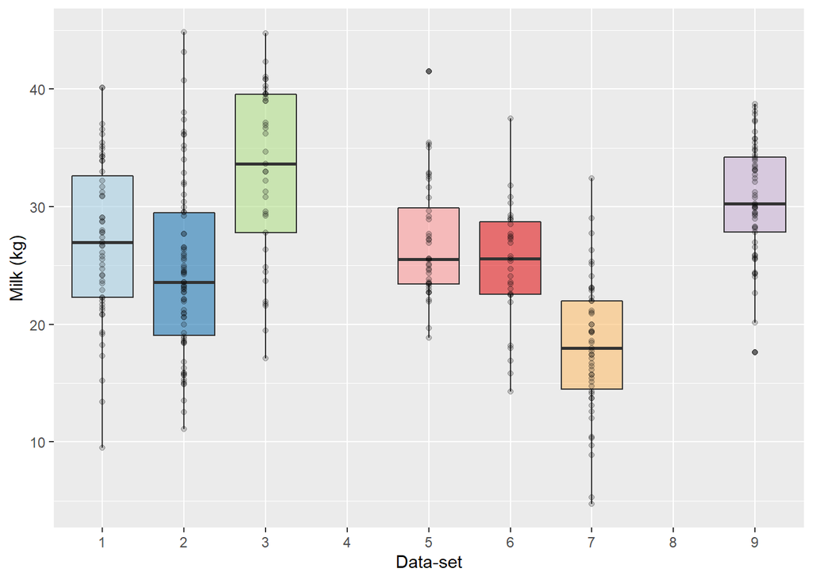

#### Week 2

| Data-set | 1 | 2 | 3 | 4 | 5 | 6 | 7 | 8 | 9 |
| --- | --- | --- | --- | --- | --- | --- | --- | --- | --- |
| Mean | 31.77587 | 33.19927 | 37.02455 |  | 39.09553 | 33.97097 | 22.75910 |  | 39.70207 |
| Median | 32.05714 | 33.97118 | 38.10215 |  | 38.41967 | 34.50000 | 22.10000 |  | 39.65584 |
| Standard Deviation | 6.750860 | 7.486358 | 7.407819 |  | 4.916402 | 5.058099 | 5.717061 |  | 4.774092 |
| Minimum | 15.22857 | 19.60187 | 21.40978 | Inf | 28.25909 | 22.10000 | 12.00000 | Inf | 21.26623 |
| Maximum | 49.80000 | 52.90885 | 49.53280 | -Inf | 50.25855 | 41.90000 | 36.70000 | -Inf | 49.14286 |

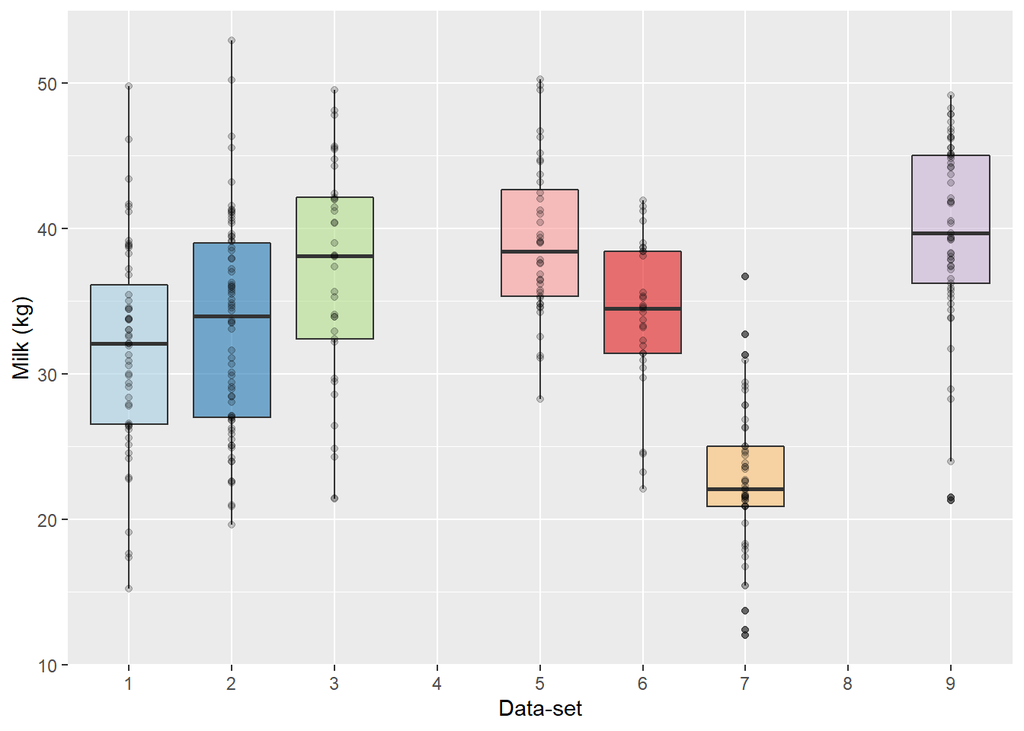

#### Week 3

| Data-set | 1 | 2 | 3 | 4 | 5 | 6 | 7 | 8 | 9 |
| --- | --- | --- | --- | --- | --- | --- | --- | --- | --- |
| Mean | 33.35901 | 35.87072 | 38.30198 | 40.35959 | 43.64511 | 37.37419 | 25.82773 | 32.26436 | 43.40877 |
| Median | 34.48571 | 36.12576 | 40.82373 | 40.72380 | 42.79688 | 38.50000 | 26.28571 | 27.70117 | 44.33766 |
| Standard Deviation | 6.750860 | 7.486358 | 7.407819 |  | 4.916402 | 5.058099 | 5.717061 |  | 4.774092 |
| Minimum | 18.50000 | 20.67106 | 12.88216 | 21.52414 | 34.01978 | 19.60000 | 16.28571 | 24.83444 | 20.95455 |
| Maximum | 46.04286 | 54.26964 | 50.34927 | 53.68096 | 56.69963 | 48.90000 | 34.70000 | 44.25746 | 53.94156 |

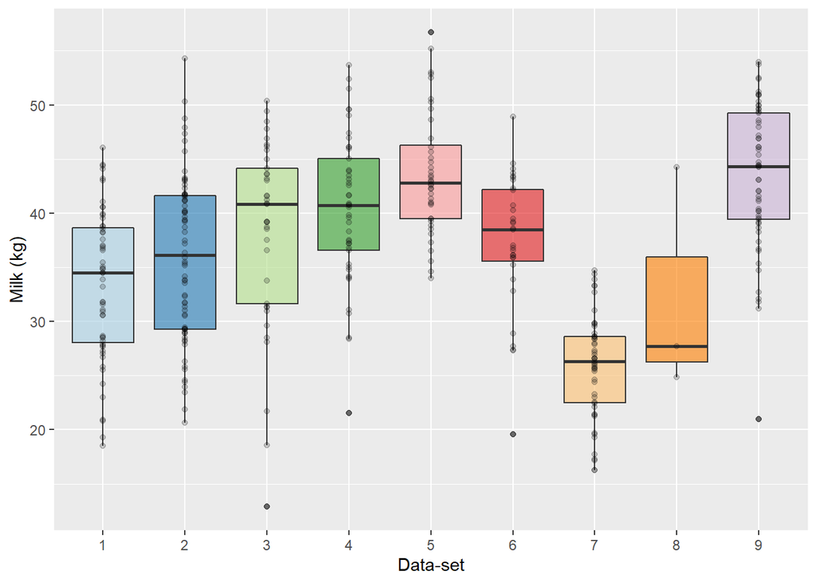

#### Week 4

| Data-set | 1 | 2 | 3 | 4 | 5 | 6 | 7 | 8 | 9 |
| --- | --- | --- | --- | --- | --- | --- | --- | --- | --- |
| Mean | 35.35579 | 37.59820 | 40.73179 | 43.20264 | 45.42888 | 39.66129 | 27.51148 | 34.28243 | 45.72761 |
| Median | 35.97143 | 38.89594 | 41.27733 | 42.22654 | 43.63603 | 40.90000 | 28.14286 | 33.08083 | 45.94156 |
| Standard Deviation | 6.750860 | 7.486358 | 7.407819 |  | 4.916402 | 5.058099 | 5.717061 |  | 4.774092 |
| Minimum | 20.34286 | 25.75783 | 24.17672 | 29.86866 | 36.92280 | 24.00000 | 18.28571 | 16.36124 | 31.83117 |
| Maximum | 51.45714 | 53.68645 | 52.79869 | 58.24366 | 59.82945 | 51.00000 | 37.60000 | 54.59494 | 54.24026 |

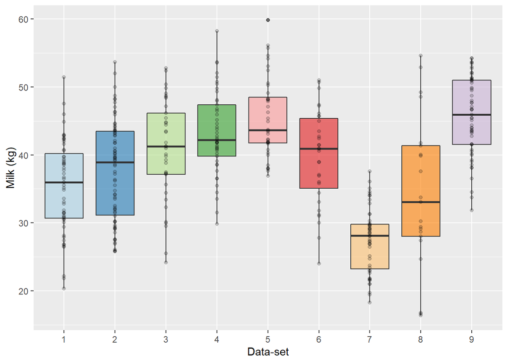

#### Week 5

| Data-set | 1 | 2 | 3 | 4 | 5 | 6 | 7 | 8 | 9 |
| --- | --- | --- | --- | --- | --- | --- | --- | --- | --- |
| Mean | 35.92021 | 39.02292 | 42.45178 | 43.91895 | 46.15463 | 39.88387 | 28.21905 | 33.79534 | 46.78380 |
| Median | 36.62857 | 40.07854 | 42.86492 | 43.40240 | 45.69990 | 41.70000 | 28.28571 | 31.03964 | 46.72078 |
| Standard Deviation | 6.750860 | 7.486358 | 7.407819 |  | 4.916402 | 5.058099 | 5.717061 |  | 4.774092 |
| Minimum | 20.77143 | 26.40583 | 32.20539 | 29.36926 | 37.14960 | 17.70000 | 19.85714 | 15.97115 | 34.74134 |
| Maximum | 50.45714 | 55.95443 | 53.84197 | 58.93374 | 60.55520 | 50.90000 | 38.28571 | 53.87825 | 58.94156 |

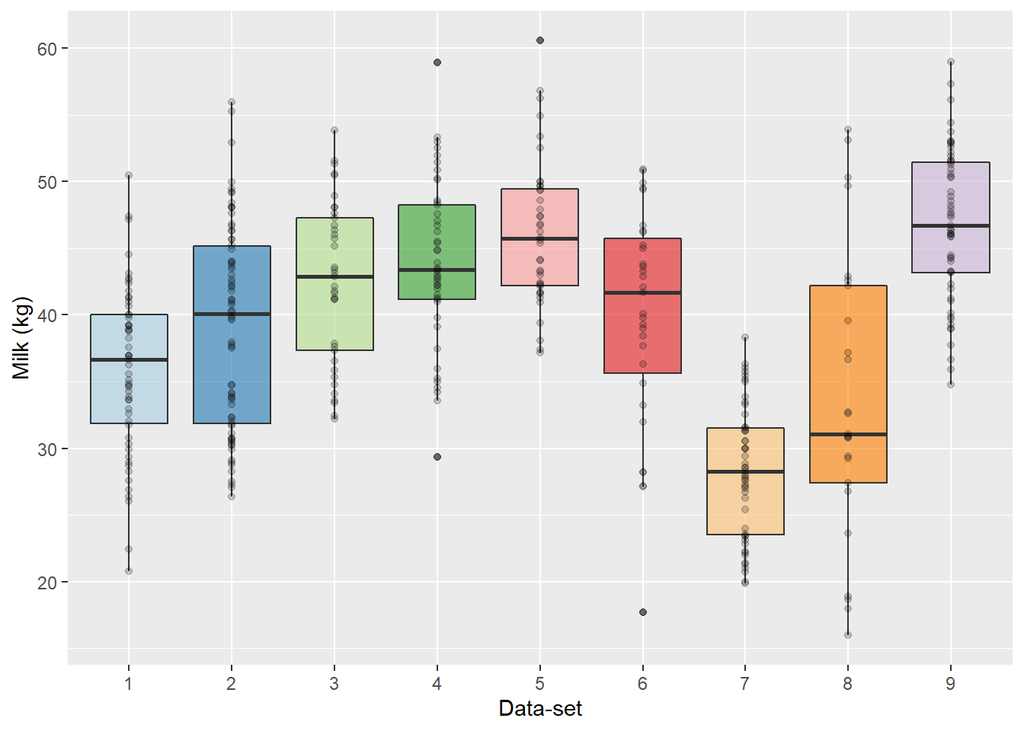

#### Week 6

| Data-set | 1 | 2 | 3 | 4 | 5 | 6 | 7 | 8 | 9 |
| --- | --- | --- | --- | --- | --- | --- | --- | --- | --- |
| Mean | 36.41431 | 39.45397 | 42.02025 | 44.34884 | 46.32473 | 41.59355 | 28.47059 | 34.69434 | 47.86945 |
| Median | 36.64286 | 41.01003 | 41.45877 | 44.95054 | 46.60709 | 43.60000 | 29.00000 | 33.01733 | 47.84740 |
| Standard Deviation | 6.750860 | 7.486358 | 7.407819 |  | 4.916402 | 5.058099 | 5.717061 |  | 4.774092 |
| Minimum | 22.20000 | 27.31302 | 32.47755 | 29.26484 | 36.65064 | 10.40000 | 20.14286 | 18.18017 | 29.00000 |
| Maximum | 50.14286 | 53.39485 | 53.52445 | 58.13924 | 60.01089 | 50.60000 | 38.14286 | 62.69164 | 61.21429 |

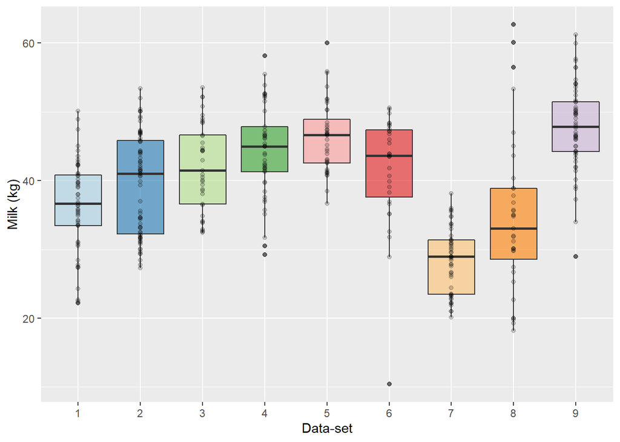

#### Week 7

| Data-set | 1 | 2 | 3 | 4 | 5 | 6 | 7 | 8 | 9 |
| --- | --- | --- | --- | --- | --- | --- | --- | --- | --- |
| Mean | 35.95644 | 39.31452 | 41.89643 | 44.16542 | 46.11154 | 41.21290 | 28.92997 | 37.04048 | 47.99313 |
| Median | 36.62857 | 40.11094 | 44.08963 | 44.65998 | 44.45251 | 42.20000 | 29.00000 | 34.77955 | 48.14286 |
| Standard Deviation | 6.750860 | 7.486358 | 7.407819 |  | 4.916402 | 5.058099 | 5.717061 |  | 4.774092 |
| Minimum | 22.50000 | 21.51346 | 26.39935 | 19.70814 | 36.15168 | 16.80000 | 20.42857 | 19.68157 | 34.85714 |
| Maximum | 51.74286 | 54.33444 | 51.71006 | 57.01786 | 60.23768 | 49.30000 | 38.14286 | 65.31797 | 61.53680 |

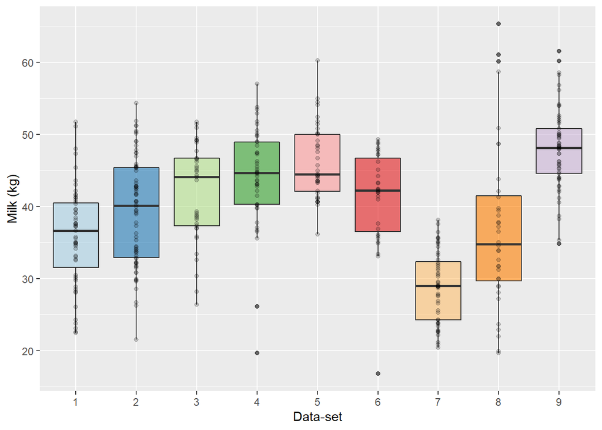

#### Week 8

| Data-set | 1 | 2 | 3 | 4 | 5 | 6 | 7 | 8 | 9 |
| --- | --- | --- | --- | --- | --- | --- | --- | --- | --- |
| Mean | 36.06236 | 39.11705 | 42.55518 | 44.40513 | 45.43681 | 41.75000 | 29.35574 | 37.88871 | 47.75042 |
| Median | 35.90000 | 40.19194 | 40.91445 | 44.40120 | 44.54323 | 42.00000 | 29.00000 | 35.96344 | 48.56818 |
| Standard Deviation | 6.750860 | 7.486358 | 7.407819 |  | 4.916402 | 5.058099 | 5.717061 |  | 4.774092 |
| Minimum | 23.27143 | 21.05986 | 32.56827 | 26.83140 | 34.74553 | 23.60000 | 21.00000 | 20.05352 | 37.07143 |
| Maximum | 53.38571 | 52.84405 | 53.07085 | 57.32204 | 57.42538 | 50.70000 | 38.42857 | 68.68820 | 60.98052 |

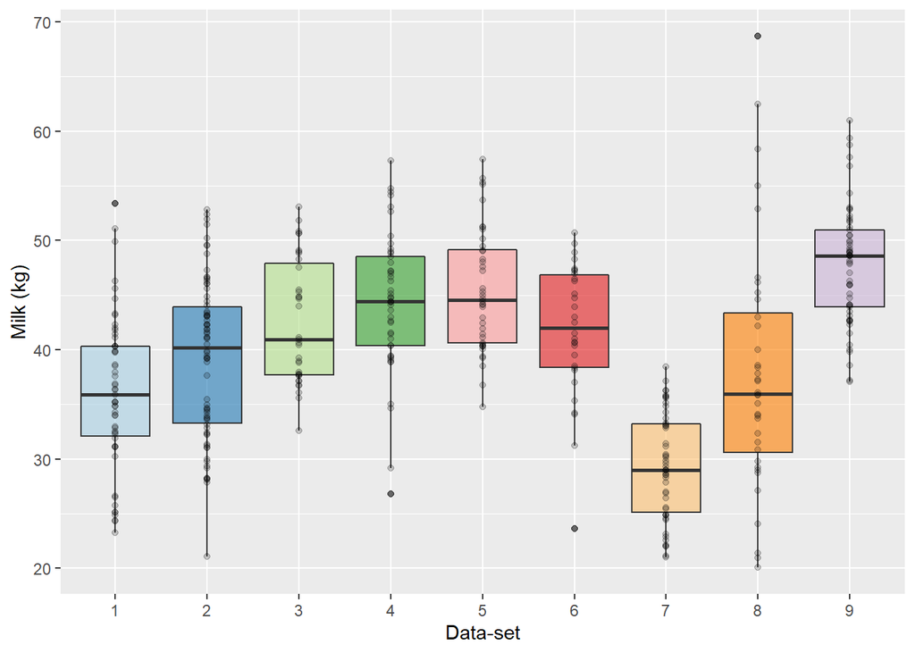

#### Week 9

| Data-set | 1 | 2 | 3 | 4 | 5 | 6 | 7 | 8 | 9 |
| --- | --- | --- | --- | --- | --- | --- | --- | --- | --- |
| Mean | 35.50553 | 38.62274 |  | 43.97252 | 45.43795 | 41.75333 | 29.30321 | 38.23848 | 47.07787 |
| Median | 35.24286 | 39.39814 |  | 44.26046 | 44.81539 | 41.85000 | 29.28571 | 37.48753 | 46.89610 |
| Standard Deviation | 6.750860 | 7.486358 | 7.407819 |  | 4.916402 | 5.058099 | 5.717061 |  | 4.774092 |
| Minimum | 22.92857 | 22.22625 | Inf | 27.93462 | 34.88161 | 26.50000 | 18.71429 | 20.54341 | 35.65584 |
| Maximum | 53.52857 | 52.35806 | -Inf | 57.58082 | 57.65218 | 50.70000 | 38.00000 | 63.59884 | 57.23506 |

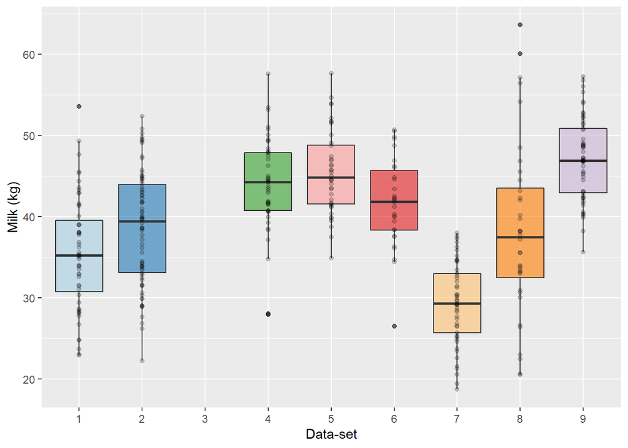

#### Week 10

| Data-set | 1 | 2 | 3 | 4 | 5 | 6 | 7 | 8 | 9 |
| --- | --- | --- | --- | --- | --- | --- | --- | --- | --- |
| Mean | 35.30319 | 38.35588 |  | 43.73190 | 44.44570 | 42.15667 | 29.43789 | 38.16389 |  |
| Median | 35.50000 | 39.15514 |  | 44.15604 | 43.84015 | 42.20000 | 29.85714 | 36.56219 |  |
| Standard Deviation | 6.750860 | 7.486358 | 7.407819 |  | 4.916402 | 5.058099 | 5.717061 |  | 4.774092 |
| Minimum | 19.74286 | 26.11423 | Inf | 27.99364 | 33.92906 | 27.20000 | 19.42857 | 20.57516 | Inf |
| Maximum | 51.14286 | 51.12686 | -Inf | 59.03816 | 58.96761 | 53.20000 | 38.14286 | 66.25692 | -Inf |

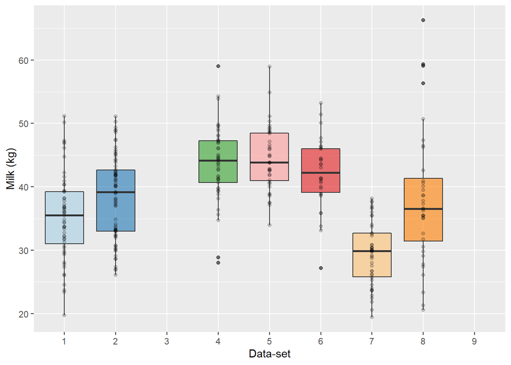

#### Week 11

| Data-set | 1 | 2 | 3 | 4 | 5 | 6 | 7 | 8 | 9 |
| --- | --- | --- | --- | --- | --- | --- | --- | --- | --- |
| Mean | 34.99919 | 37.62360 |  | 42.34872 | 43.12574 |  | 29.59801 | 38.69447 |  |
| Median | 34.41429 | 38.19935 |  | 41.40480 | 42.29792 |  | 29.85714 | 38.37658 |  |
| Standard Deviation | 6.750860 | 7.486358 | 7.407819 |  | 4.916402 | 5.058099 | 5.717061 |  | 4.774092 |
| Minimum | 21.25714 | 26.24383 | Inf | 28.27966 | 32.34147 | Inf | 19.57143 | 19.92652 | Inf |
| Maximum | 51.94286 | 53.97805 | -Inf | 57.00878 | 54.47700 | -Inf | 39.00000 | 65.90311 | -Inf |

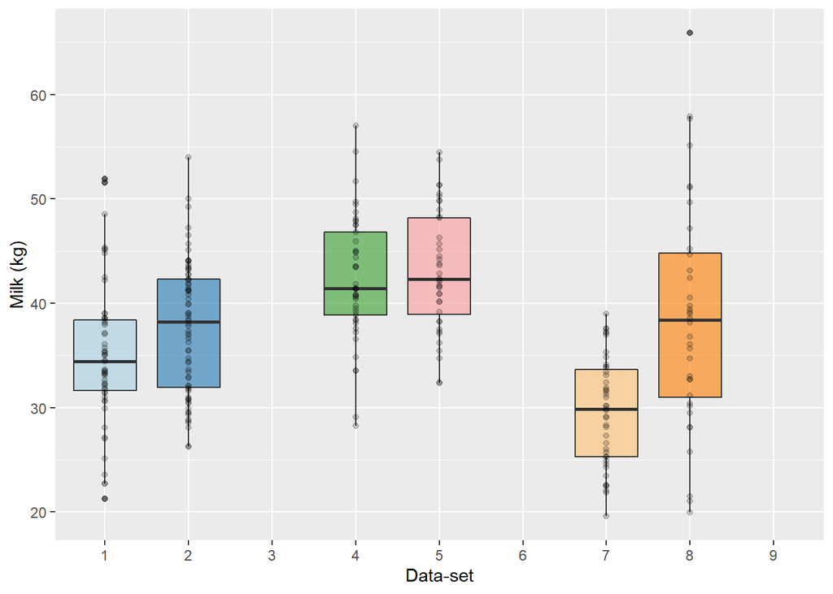

#### Week 12

| Data-set | 1 | 2 | 3 | 4 | 5 | 6 | 7 | 8 | 9 |
| --- | --- | --- | --- | --- | --- | --- | --- | --- | --- |
| Mean | 34.60917 | 37.19426 |  | 42.51044 | 42.40565 |  | 29.18315 | 38.75785 |  |
| Median | 33.81429 | 37.56755 |  | 42.18114 | 42.59276 |  | 29.57143 | 37.68030 |  |
| Standard Deviation | 6.750860 | 7.486358 | 7.407819 |  | 4.916402 | 5.058099 | 5.717061 |  | 4.774092 |
| Minimum | 21.28571 | 24.88304 | Inf | 29.13318 | 33.33938 | Inf | 17.28571 | 20.70217 | Inf |
| Maximum | 50.80000 | 51.87206 | -Inf | 54.77056 | 53.43373 | -Inf | 39.71429 | 59.71151 | -Inf |

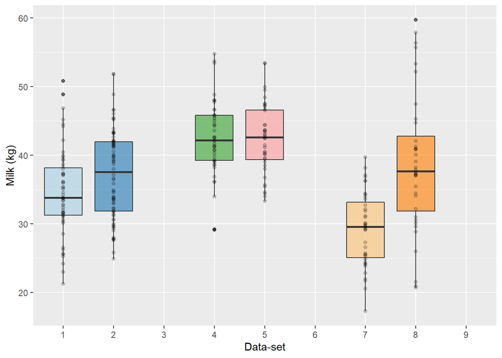

#### Week 13

| Data-set | 1 | 2 | 3 | 4 | 5 | 6 | 7 | 8 | 9 |
| --- | --- | --- | --- | --- | --- | --- | --- | --- | --- |
| Mean | 33.43395 | 36.81141 |  | 41.60496 | 41.13218 |  | 29.30502 | 38.42320 |  |
| Median | 32.72857 | 36.12576 |  | 42.61244 | 41.36805 |  | 29.14286 | 37.21083 |  |
| Standard Deviation | 6.750860 | 7.486358 | 7.407819 |  | 4.916402 | 5.058099 | 5.717061 |  | 4.774092 |
| Minimum | 19.28571 | 23.74904 | Inf | 29.27846 | 30.88996 | Inf | 20.85714 | 14.54686 | Inf |
| Maximum | 50.24286 | 49.66887 | -Inf | 57.76242 | 54.34092 | -Inf | 38.42857 | 59.81130 | -Inf |

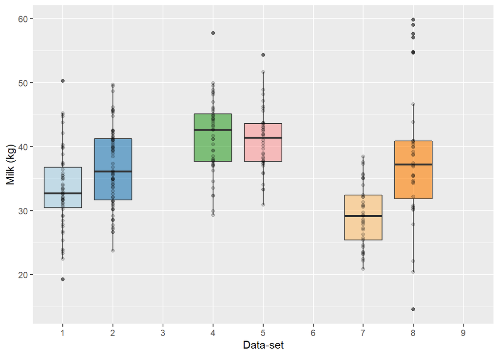

#### Week 14

| Data-set | 1 | 2 | 3 | 4 | 5 | 6 | 7 | 8 | 9 |
| --- | --- | --- | --- | --- | --- | --- | --- | --- | --- |
| Mean | 33.26621 | 36.40795 |  | 41.12786 | 40.12292 |  | 29.41699 | 39.07738 |  |
| Median | 32.35714 | 35.86656 |  | 41.40480 | 39.34954 |  | 29.28571 | 38.36070 |  |
| Standard Deviation | 6.750860 | 7.486358 | 7.407819 |  | 4.916402 | 5.058099 | 5.717061 |  | 4.774092 |
| Minimum | 19.12857 | 24.33224 | Inf | 27.90284 | 28.34981 | Inf | 20.42857 | 19.24612 | Inf |
| Maximum | 50.65714 | 49.40968 | -Inf | 57.69886 | 55.97387 | -Inf | 37.28571 | 61.78445 | -Inf |

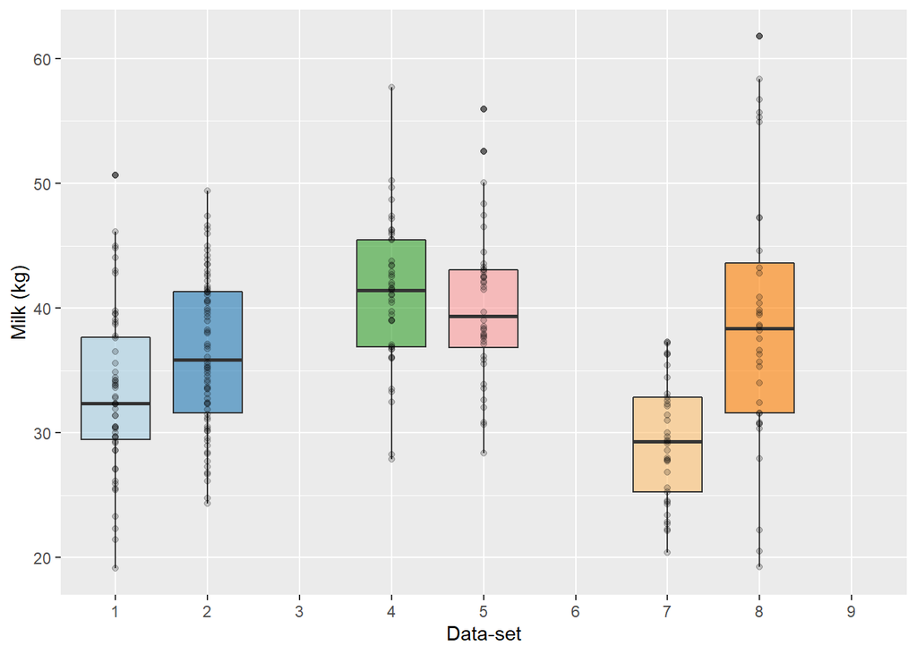

#### Week 15

| Data-set | 1 | 2 | 3 | 4 | 5 | 6 | 7 | 8 | 9 |
| --- | --- | --- | --- | --- | --- | --- | --- | --- | --- |
| Mean | 33.04081 | 35.67151 |  | 40.40822 | 38.96739 |  |  | 38.22840 |  |
| Median | 32.58571 | 35.21857 |  | 39.97924 | 39.19078 |  |  | 36.49642 |  |
| Standard Deviation | 6.750860 | 7.486358 | 7.407819 |  | 4.916402 | 5.058099 | 5.717061 |  | 4.774092 |
| Minimum | 19.81429 | 23.78144 | Inf | 28.57476 | 28.25909 | Inf | Inf | 18.59748 | Inf |
| Maximum | 47.40000 | 47.27129 | -Inf | 55.87378 | 52.20902 | -Inf | -Inf | 61.75270 | -Inf |

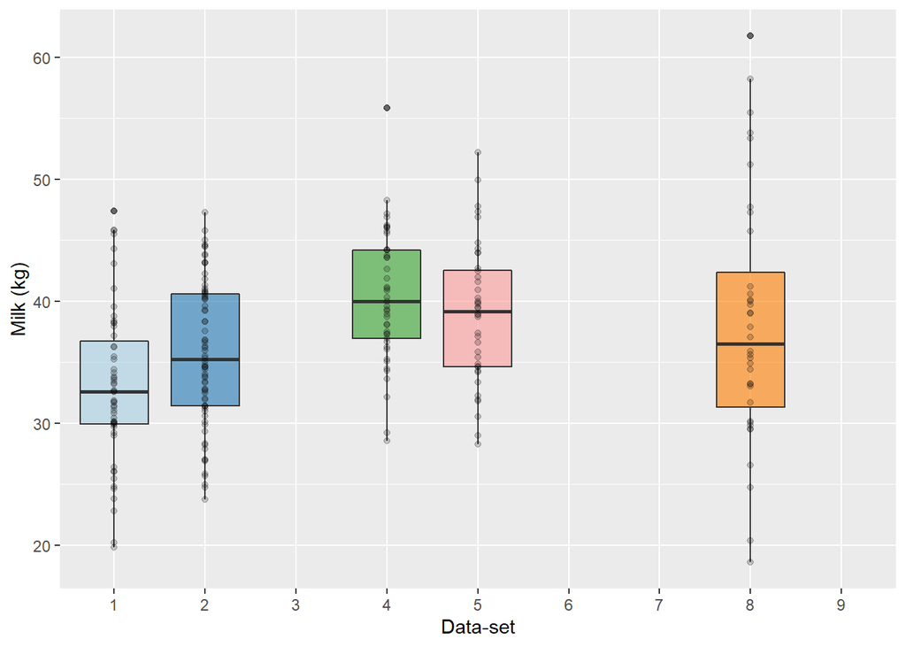

#### Week 16

| Data-set | 1 | 2 | 3 | 4 | 5 | 6 | 7 | 8 | 9 |
| --- | --- | --- | --- | --- | --- | --- | --- | --- | --- |
| Mean | 32.50803 | 35.16647 |  | 39.92133 | 38.89368 |  |  | 37.98951 |  |
| Median | 31.74286 | 34.74877 |  | 40.51496 | 38.69183 |  |  | 36.56219 |  |
| Standard Deviation | 6.750860 | 7.486358 | 7.407819 |  | 4.916402 | 5.058099 | 5.717061 |  | 4.774092 |
| Minimum | 16.18571 | 22.11285 | Inf | 26.87680 | 28.62197 | Inf | Inf | 18.76077 | Inf |
| Maximum | 46.30000 | 45.52170 | -Inf | 49.09102 | 52.66261 | -Inf | -Inf | 62.43309 | -Inf |

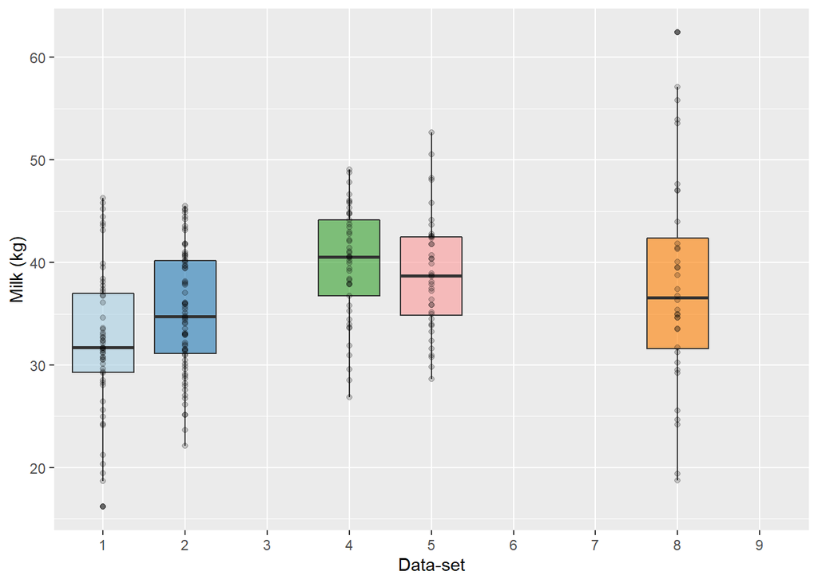

#### Week 17

| Data-set | 1 | 2 | 3 | 4 | 5 | 6 | 7 | 8 | 9 |
| --- | --- | --- | --- | --- | --- | --- | --- | --- | --- |
| Mean | 32.01584 | 34.76585 |  | 39.36008 | 37.57031 |  |  | 36.99235 |  |
| Median | 31.62857 | 34.47337 |  | 39.11664 | 36.78672 |  |  | 37.06568 |  |
| Standard Deviation | 6.750860 | 7.486358 | 7.407819 |  | 4.916402 | 5.058099 | 5.717061 |  | 4.774092 |
| Minimum | 19.65714 | 22.71225 | Inf | 27.54418 | 27.71478 | Inf | Inf | 18.17563 | Inf |
| Maximum | 46.94286 | 45.10050 | -Inf | 51.89674 | 49.71423 | -Inf | -Inf | 62.59639 | -Inf |

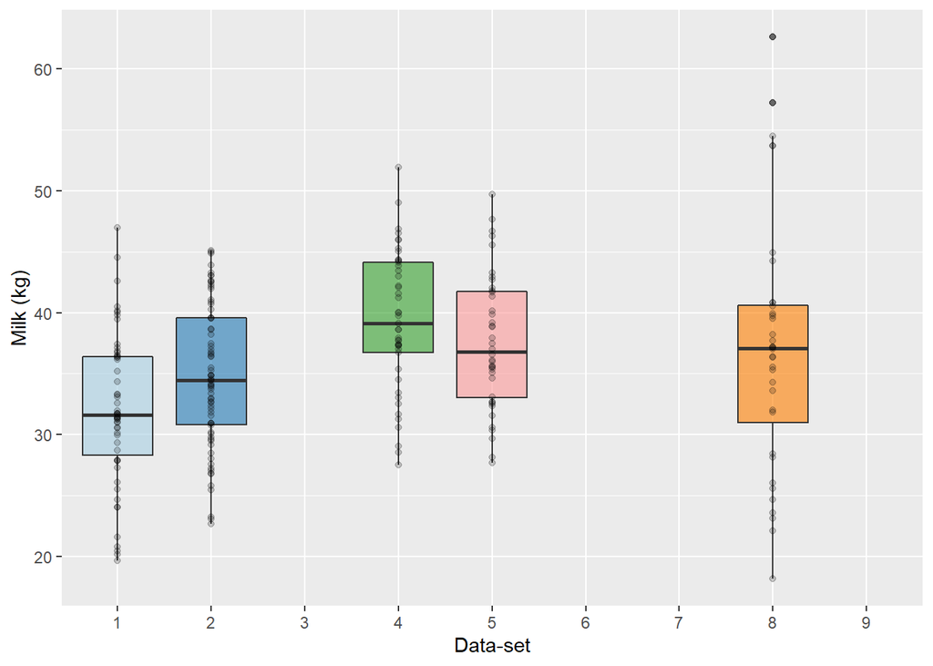

#### Week 18

| Data-set | 1 | 2 | 3 | 4 | 5 | 6 | 7 | 8 | 9 |
| --- | --- | --- | --- | --- | --- | --- | --- | --- | --- |
| Mean | 31.41200 | 33.89784 |  | 38.38671 | 36.19931 |  |  | 36.71540 |  |
| Median | 31.21429 | 33.20978 |  | 38.10876 | 36.60528 |  |  | 35.73664 |  |
| Standard Deviation | 6.750860 | 7.486358 | 7.407819 |  | 4.916402 | 5.058099 | 5.717061 |  | 4.774092 |
| Minimum | 18.55714 | 22.55025 | Inf | 25.72818 | 22.95201 | Inf | Inf | 17.72204 | Inf |
| Maximum | 45.18571 | 44.91421 | -Inf | 54.03962 | 48.08128 | -Inf | -Inf | 62.17454 | -Inf |

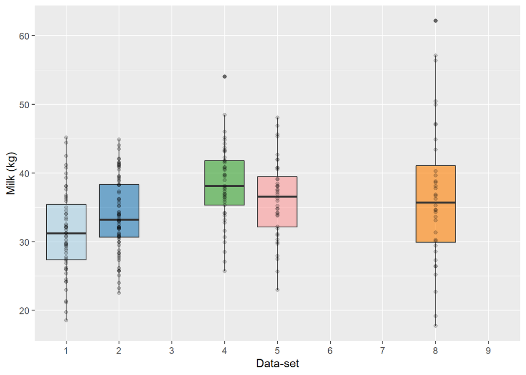

#### Week 19

| Data-set | 1 | 2 | 3 | 4 | 5 | 6 | 7 | 8 | 9 |
| --- | --- | --- | --- | --- | --- | --- | --- | --- | --- |
| Mean | 30.83514 | 33.26626 |  |  | 35.00295 |  |  | 33.68374 |  |
| Median | 30.68571 | 32.85338 |  |  | 35.44861 |  |  | 33.12846 |  |
| Standard Deviation | 6.750860 | 7.486358 | 7.407819 |  | 4.916402 | 5.058099 | 5.717061 |  | 4.774092 |
| Minimum | 17.071429 | 22.453053 | Inf | Inf | 22.180894 | Inf | Inf | 7.860836 | Inf |
| Maximum | 46.27143 | 45.13290 | -Inf | -Inf | 45.72258 | -Inf | -Inf | 58.38247 | -Inf |

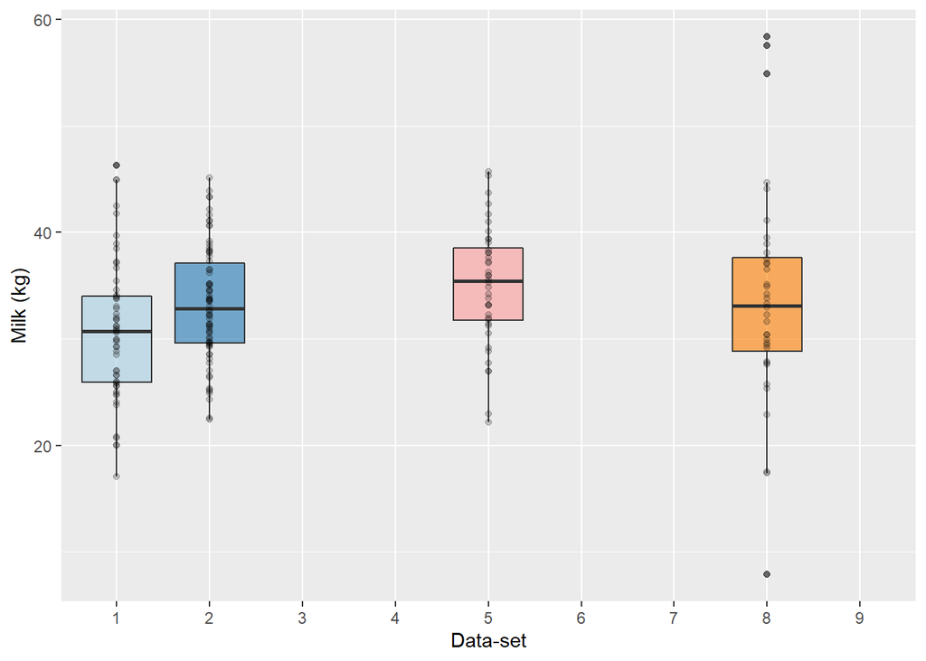

#### Week 20

| Data-set | 1 | 2 | 3 | 4 | 5 | 6 | 7 | 8 | 9 |
| --- | --- | --- | --- | --- | --- | --- | --- | --- | --- |
| Mean | 29.96229 | 32.66730 |  |  | 33.34278 |  |  | 32.71254 |  |
| Median | 29.51429 | 32.59419 |  |  | 33.33938 |  |  | 33.17835 |  |
| Standard Deviation | 6.750860 | 7.486358 | 7.407819 |  | 4.916402 | 5.058099 | 5.717061 |  | 4.774092 |
| Minimum | 17.814286 | 22.355853 | Inf | Inf | 18.143881 | Inf | Inf | 8.455049 | Inf |
| Maximum | 47.58571 | 45.29490 | -Inf | -Inf | 45.49578 | -Inf | -Inf | 58.86782 | -Inf |

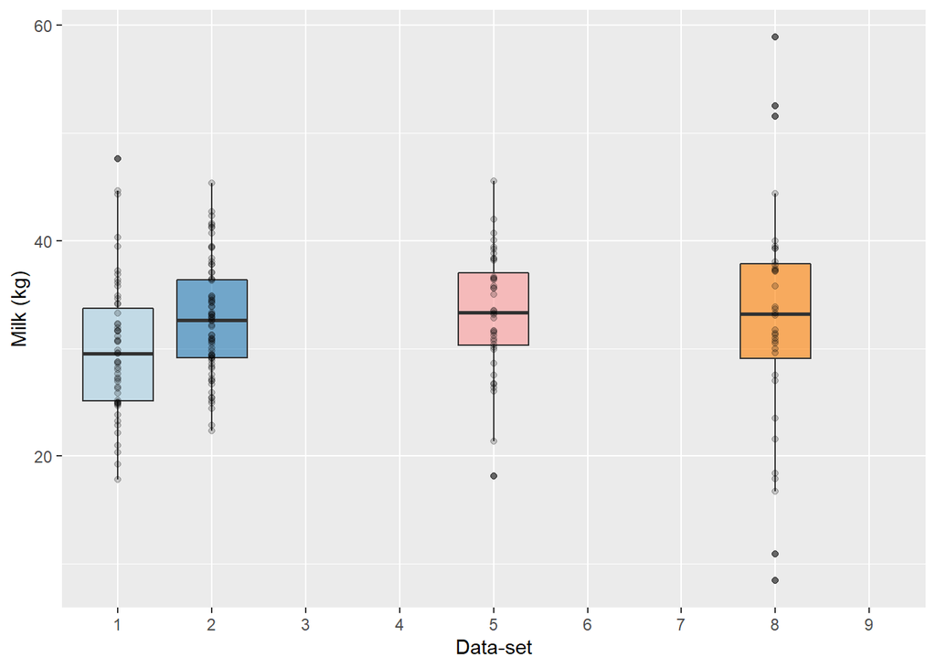

#### Week 21

| Data-set | 1 | 2 | 3 | 4 | 5 | 6 | 7 | 8 | 9 |
| --- | --- | --- | --- | --- | --- | --- | --- | --- | --- |
| Mean | 29.67213 | 32.10140 |  |  | 32.50930 |  |  | 32.50023 |  |
| Median | 29.55714 | 31.54119 |  |  | 32.31879 |  |  | 32.82001 |  |
| Standard Deviation | 6.750860 | 7.486358 | 7.407819 |  | 4.916402 | 5.058099 | 5.717061 |  | 4.774092 |
| Minimum | 17.61429 | 23.03625 | Inf | Inf | 12.02032 | Inf | Inf | 11.11313 | Inf |
| Maximum | 44.01429 | 44.35531 | -Inf | -Inf | 44.27107 | -Inf | -Inf | 57.60682 | -Inf |

[figure not shown]

#### Week 22

| Data-set | 1 | 2 | 3 | 4 | 5 | 6 | 7 | 8 | 9 |
| --- | --- | --- | --- | --- | --- | --- | --- | --- | --- |
| Mean | 28.99317 | 31.61453 |  |  |  |  |  | 33.43827 |  |
| Median | 27.85714 | 31.21720 |  |  |  |  |  | 33.62968 |  |
| Standard Deviation | 6.750860 | 7.486358 | 7.407819 |  | 4.916402 | 5.058099 | 5.717061 |  | 4.774092 |
| Minimum | 16.64286 | 22.12905 | Inf | Inf | Inf | Inf | Inf | 14.22480 | Inf |
| Maximum | 44.61429 | 43.57771 | -Inf | -Inf | -Inf | -Inf | -Inf | 58.90411 | -Inf |

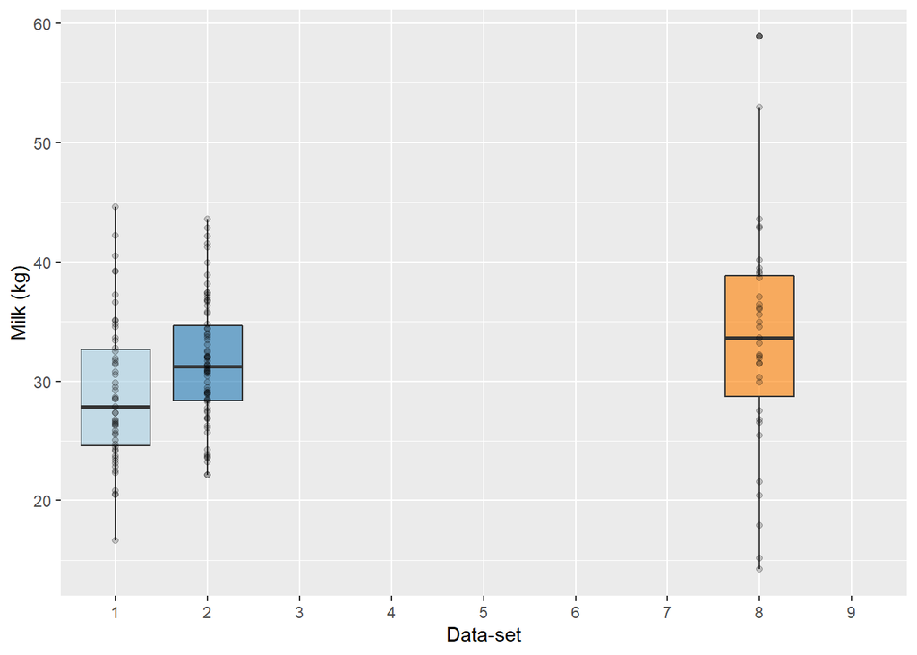

#### Week 23

| Data-set | 1 | 2 | 3 | 4 | 5 | 6 | 7 | 8 | 9 |
| --- | --- | --- | --- | --- | --- | --- | --- | --- | --- |
| Mean | 27.77449 | 31.02192 |  |  |  |  |  | 32.77871 |  |
| Median | 27.34286 | 30.76360 |  |  |  |  |  | 32.46394 |  |
| Standard Deviation | 6.750860 | 7.486358 | 7.407819 |  | 4.916402 | 5.058099 | 5.717061 |  | 4.774092 |
| Minimum | 15.628571 | 21.675458 | Inf | Inf | Inf | Inf | Inf | 8.749887 | Inf |
| Maximum | 44.05714 | 42.47612 | -Inf | -Inf | -Inf | -Inf | -Inf | 58.31897 | -Inf |

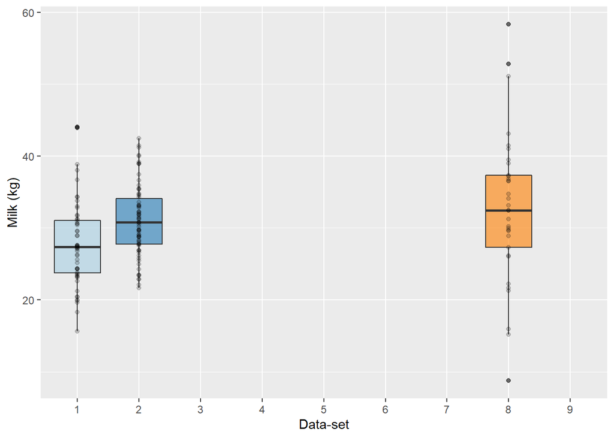

#### Week 24

| Data-set | 1 | 2 | 3 | 4 | 5 | 6 | 7 | 8 | 9 |
| --- | --- | --- | --- | --- | --- | --- | --- | --- | --- |
| Mean | 27.28364 | 30.47309 |  |  |  |  |  | 32.90517 |  |
| Median | 26.87143 | 30.24520 |  |  |  |  |  | 33.11258 |  |
| Standard Deviation | 6.750860 | 7.486358 | 7.407819 |  | 4.916402 | 5.058099 | 5.717061 |  | 4.774092 |
| Minimum | 15.57143 | 20.86546 | Inf | Inf | Inf | Inf | Inf | 13.51266 | Inf |
| Maximum | 43.15714 | 41.43933 | -Inf | -Inf | -Inf | -Inf | -Inf | 58.83607 | -Inf |

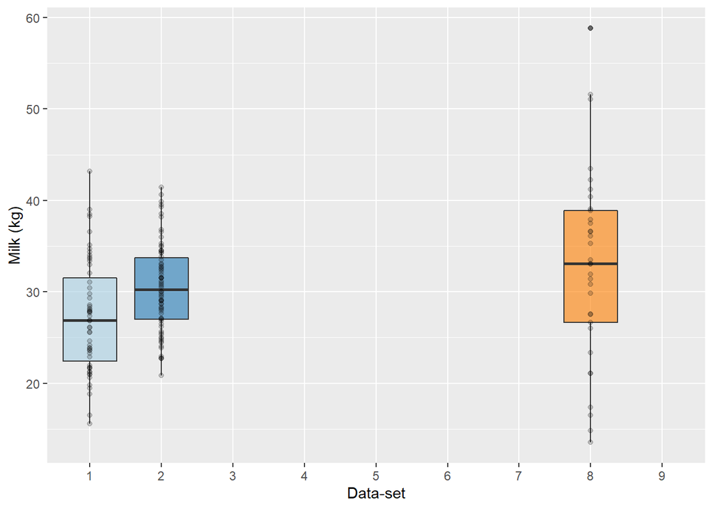

#### Week 25

| Data-set | 1 | 2 | 3 | 4 | 5 | 6 | 7 | 8 | 9 |
| --- | --- | --- | --- | --- | --- | --- | --- | --- | --- |
| Mean | 27.07977 | 29.61757 |  |  |  |  |  | 31.77914 |  |
| Median | 25.98571 | 30.03460 |  |  |  |  |  | 30.45450 |  |
| Standard Deviation | 6.750860 | 7.486358 | 7.407819 |  | 4.916402 | 5.058099 | 5.717061 |  | 4.774092 |
| Minimum | 13.48571 | 18.79188 | Inf | Inf | Inf | Inf | Inf | 14.09326 | Inf |
| Maximum | 43.47143 | 41.73093 | -Inf | -Inf | -Inf | -Inf | -Inf | 53.58795 | -Inf |

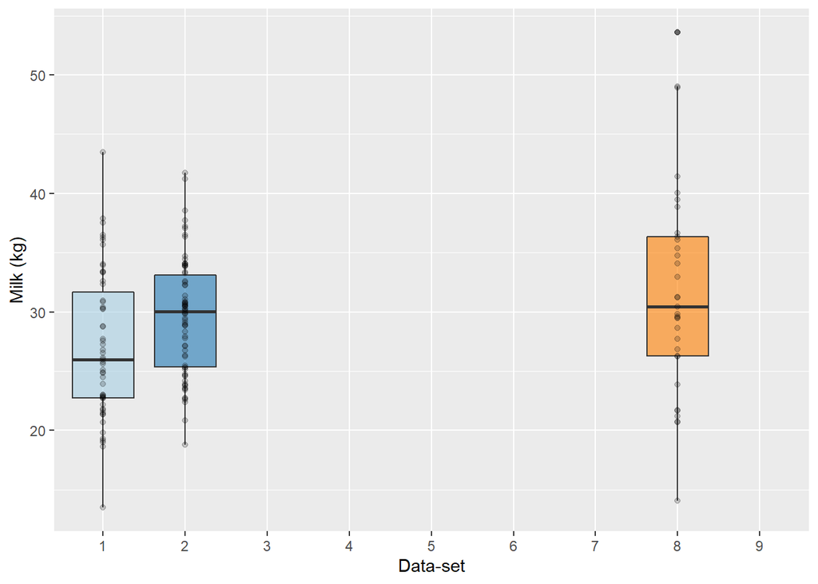

#### Week 26

| Data-set | 1 | 2 | 3 | 4 | 5 | 6 | 7 | 8 | 9 |
| --- | --- | --- | --- | --- | --- | --- | --- | --- | --- |
| Mean | 26.39088 | 29.37413 |  |  |  |  |  | 32.24662 |  |
| Median | 26.17143 | 29.40281 |  |  |  |  |  | 31.03964 |  |
| Standard Deviation | 6.750860 | 7.486358 | 7.407819 |  | 4.916402 | 5.058099 | 5.717061 |  | 4.774092 |
| Minimum | 13.72857 | 19.08347 | Inf | Inf | Inf | Inf | Inf | 13.12256 | Inf |
| Maximum | 42.68571 | 41.66613 | -Inf | -Inf | -Inf | -Inf | -Inf | 53.81475 | -Inf |

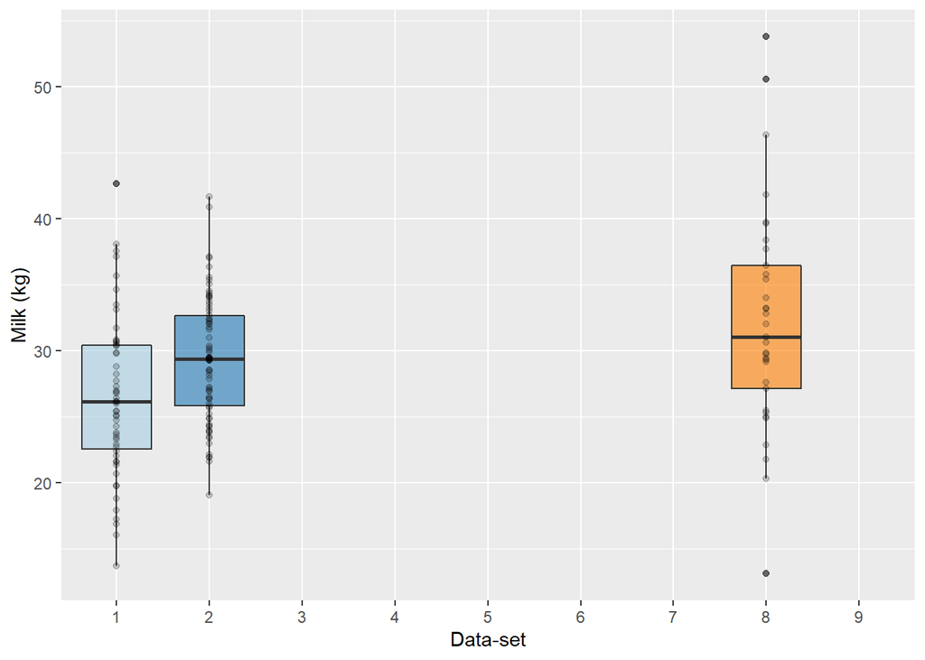

#### Week 27

| Data-set | 1 | 2 | 3 | 4 | 5 | 6 | 7 | 8 | 9 |
| --- | --- | --- | --- | --- | --- | --- | --- | --- | --- |
| Mean | 26.05655 | 28.84763 |  |  |  |  |  | 31.38836 |  |
| Median | 25.04286 | 28.47941 |  |  |  |  |  | 31.16665 |  |
| Standard Deviation | 6.750860 | 7.486358 | 7.407819 |  | 4.916402 | 5.058099 | 5.717061 |  | 4.774092 |
| Minimum | 14.20000 | 19.31027 | Inf | Inf | Inf | Inf | Inf | 13.80296 | Inf |
| Maximum | 42.82857 | 40.40253 | -Inf | -Inf | -Inf | -Inf | -Inf | 47.72294 | -Inf |

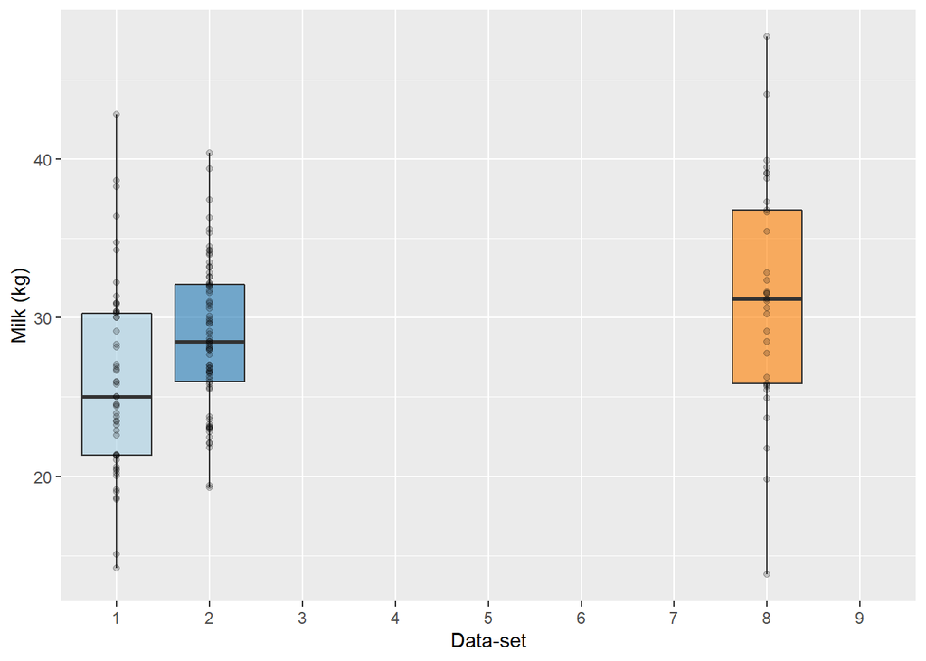

#### Week 28

| Data-set | 1 | 2 | 3 | 4 | 5 | 6 | 7 | 8 | 9 |
| --- | --- | --- | --- | --- | --- | --- | --- | --- | --- |
| Mean | 25.07662 | 28.34325 |  |  |  |  |  | 30.12709 |  |
| Median | 23.68571 | 28.23641 |  |  |  |  |  | 31.65654 |  |
| Standard Deviation | 6.750860 | 7.486358 | 7.407819 |  | 4.916402 | 5.058099 | 5.717061 |  | 4.774092 |
| Minimum | 12.742857 | 17.398686 | Inf | Inf | Inf | Inf | Inf | 9.008437 | Inf |
| Maximum | 41.55714 | 38.62055 | -Inf | -Inf | -Inf | -Inf | -Inf | 50.38102 | -Inf |

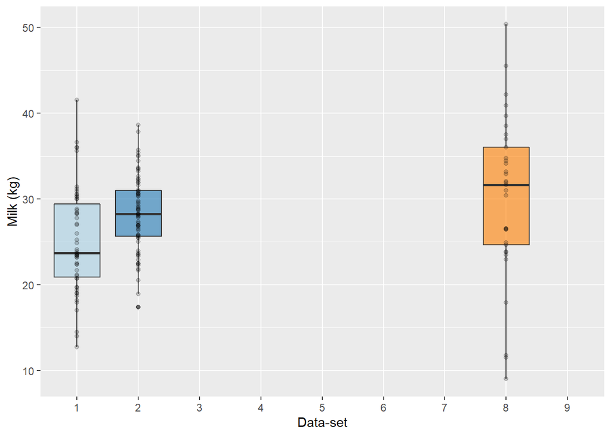